# R Notebook

##### Modelo propuesto

```r
summary(regresion)
```

```
##
## Call:
## lm(formula = y ~ x, data = data)
##
## Residuals:
##     Min      1Q  Median      3Q     Max
## -3.3733 -0.5729  0.1705  0.6837  2.4841
##
## Coefficients:
##             Estimate Std. Error t value Pr(>|t|)
## (Intercept)  6.08825    0.18590  32.750   <2e-16 ***
## x            0.02851    0.01177   2.423   0.0166 *
## ---
## Signif. codes:  0 '***' 0.001 '**' 0.01 '*' 0.05 '.' 0.1 ' ' 1
##
## Residual standard error: 1.101 on 151 degrees of freedom
## Multiple R-squared:  0.03742,    Adjusted R-squared:  0.03105
## F-statistic: 5.871 on 1 and 151 DF,  p-value: 0.01658
```

$$\text{Y = 6.09 + 0.03X}$$

##### Prueba de hipotesis para el Intercepto (ßo)

Ho: ßo = 0  
H1: ßo ≠ 0

Se obtiene un p-valor = 2e-16 menor a α = 0.05, se rechaza H0, entonces ßo no es cero.

Ho: ß1 = 0  
H1: ß1 ≠ 0

Se obtiene un p-valor = 0.0166 menor a α = 0.05, se rechaza H0, entonces ß1 no es cero.

###### R cuadrado

El R-cuadrado cercano a cero indica que el modelo no explica en gran medida la relación de las variables.

##### R correlación

```
##           y         x
## y 1.0000000 0.1934501
## x 0.1934501 1.0000000
```

La correlación calculada indica que las variables están débilmente relacionadas.

##### Gráfica

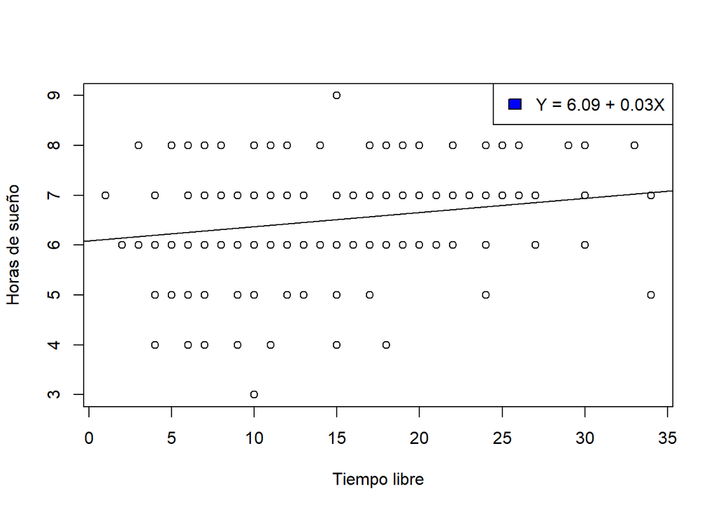

##### Predicción de valores

```r
nuevos.x <- data.frame(x = c(36,38,40,41,42,43))
predict(regresion,nuevos.x)
```

```
##        1        2        3        4        5        6
## 7.114607 7.171627 7.228647 7.257157 7.285667 7.314177
```

Mientras más horas de tiempo libre tengas, duermes un poco más. Pero, esta cantidad que aumenta no es muy significativa que digamos.

#### ¿Las horas de estudio definen al tiempo libre?

Consideramos que mientras más horas de estudio, menos tiempo libre. Se analizará:  
X= Horas de estudio  
Y= Tiempo libre

##### Supuestos:

Distribución normal de los errores:

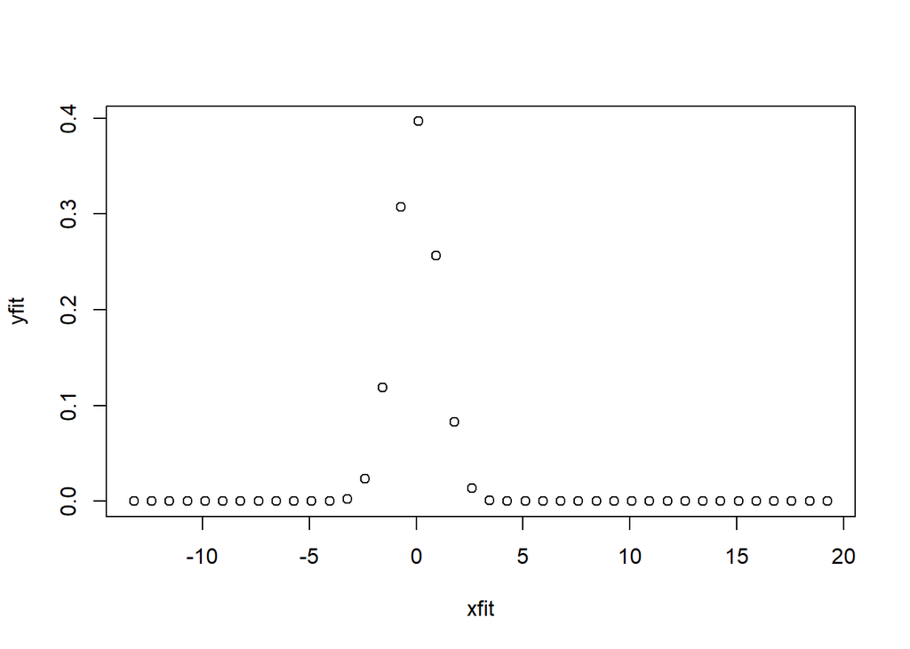

Media de los errores:

```r
mean(regresion$residuals)
```

```
## [1] 5.655482e-16
```

La distribución normal de los errores no se cumple. Por lo tanto, no tiene sentido seguir haciendo la regresión.

### ¿La edad define a las horas dedicadas a los videojuegos?

Queremos comprobar si la edad influye realmente en el interés de videojuegos. Se analizará.  
X: Edad  
Y: Horas de videojuegos

##### Supuestos:

Distribución normal de los errores:

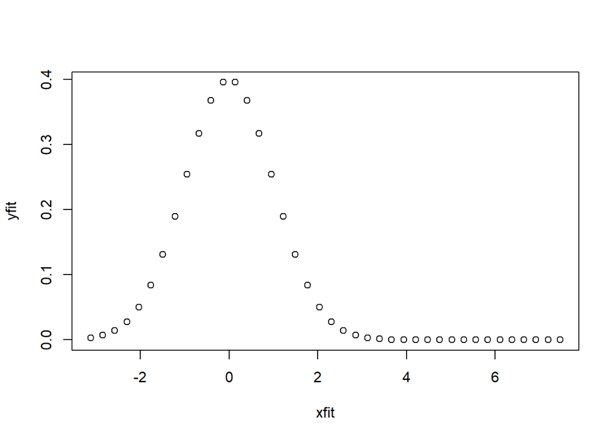

Media de los errores:

```r
mean(regresion$residuals)
```

```
## [1] -1.197639e-16
```

A partir de esto consideramos que podríamos hacer la regresión lineal.

##### Modelo propuesto

```r
summary(regresion)
```

```
##
## Call:
## lm(formula = y ~ x, data = data)
##
## Residuals:
##    Min     1Q Median     3Q    Max
## -3.123 -2.828 -1.024  1.976  7.467
##
## Coefficients:
##             Estimate Std. Error t value Pr(>|t|)
## (Intercept)  4.79302    2.50340   1.915   0.0574 .
## x           -0.09826    0.13075  -0.751   0.4535
## ---
## Signif. codes:  0 '***' 0.001 '**' 0.01 '*' 0.05 '.' 0.1 ' ' 1
##
## Residual standard error: 3.162 on 151 degrees of freedom
## Multiple R-squared:  0.003726,   Adjusted R-squared:  -0.002872
## F-statistic: 0.5647 on 1 and 151 DF,  p-value: 0.4535
```

$$\text{Y = 4.79 - 0.098X}$$

##### Prueba de hipotesis para el Intercepto (ßo)

Ho: ßo = 0  
H1: ßo ≠ 0

Se obtiene un p-valor = 0.0575 mayor a α = 0.05, se acepta H0, entonces ßo es cero, y no existirá intercepto para el modelo.

##### Prueba de hipotesis para el coeficiente de edad (ß1)

Ho: ß1 = 0  
H1: ß1 ≠ 0

Se obtiene un p-valor = 0.4535 mayor a α = 0.05, se acepta H0, entonces ß1 es cero, entonces las variables no están relacionadas.

##### R cuadrado

El R-cuadrado cercano a cero indica que el modelo no explica en gran medida la relación de las variables.

##### R correlación

```
##             y           x
## y  1.00000000 -0.06104129
## x -0.06104129  1.00000000
```

La correlación calculada indica que las variables están débilmente relacionadas.

Después de analizar lo anterior, se afirma que no existe un modelo que pueda explicar la dependencia entre la edad y horas usadas en videojuegos, pues la variable no están relacionadas.

##### Gráfica y predicción de valores

No tiene sentido hacer una gráfica ni una predicción de valores. Las hipótesis para el $B_0$ y $B_1$ no rechazan, eso quiere decir que nuestro modelo es igual a una constante (0).

## Conclusiones y reflexiones

Este estudio por la parte descriptiva y la inferencial llego a los siguientes resultados:

- Los estudiantes de UTEC no juegan mucho a los videojuegos. Usando la variable aleatoria que habla de horas de videojuegos y carreras, encontramos que hay carreras que juegan más que otras.
- Viendo los gráficos encontramos que la actividad más realizada es redes sociales. Eso quiere decir que si lo comparamos con el deporte los estudiantes usan más las redes sociales. También se demostró esto usando una prueba de hipótesis de resta de medias. Donde se rechazó la hipótesis nula que decía que se dedicaba más tiempo al deporte que a las redes sociales. Esto es preocupante, la salud de los estudiantes de UTEC no se cuida mucho.
- Viendo los gráficos encontramos que la mayoría de personas (81%) duermen entre 4 y 7 horas. Al separar a los estudiantes en grupos con asistencia financiera y sin asistencia financiera y realizarle una prueba de hipótesis a su media de horas de sueño, descubrimos lo mismo. No importa el grupo al que pertenezcas (becado o no), la media de horas de sueño va a ser diferente de 8.
- Se puede decir que los estudiantes de ingeniería tienen 2 horas promedio diarias de tiempo libre. Este dato habría compararlo con las horas de tiempo libre en otras universidades.
- Tratamos de modelar 3 modelos: el tiempo libre vs horas de sueño, horas de estudio vs tiempo libre, edad vs horas dedicadas a los videojuegos. El único modelo que resulto exitoso fue el tiempo libre vs horas de sueño. En la muestra, mientras más tiempo libre tengas más dormirás.
- Sería interesante realizar una reencuesta de nuestros datos, con otro enfoque. Donde buscaríamos encontrar las diferencias entre los estudiantes de ingeniería de UTEC de sexo femenino y los estudiantes de ingeniería de UTEC de sexo masculino. En esta reencuesta sería necesario buscar variables numéricas continuas, para hacer una regresión satisfactoria. Apartado que no se vio mucho en nuestro trabajo.